# Reviewer Response Analyses

## Setup

```
n_samples=6768, n_features=84, n_proteins=376, n_npunid=18, enriched_rate=0.391
```

### Shared helpers

Confidence intervals across folds, out-of-fold prediction for an arbitrary model, and the metric set used throughout. Every section below reuses these, so all reported numbers are produced by the same code path.

## Major 1. Leave-one-nanoparticle-out validation

> *The analysis includes many protein-nanoparticle observations, but only 11 unique nanoparticles. Therefore, conclusions about zeta potential, size, core material, and surface coating are based on a very small nanoparticle sample. The authors should emphasize this limitation and provide leave-one-nanoparticle-out validation or nanoparticle-level resampling.*

`npunid` is not a nanoparticle, it is a nanoparticle x incubation-concentration condition.

`npunid` 23 and 30 are the same nanoparticle, run at 40 and 4 mg/mL, but the excel file records d_TEM as 182 nm for one and 244 nm for the other. The two are merged here **for grouping only**: the `dtem` column is left exactly as recorded, so no model input changes and the merge affects fold membership alone.

```
{'npunid': 18, 'np_material': 11}
```

| np_material | core | ligand | dtem | zeta | n_npunid | npunids | label |
| --- | --- | --- | --- | --- | --- | --- | --- |
| 0 | PS | carboxylate | 200 | -63 | 2 | 17,18 | PS/carboxylate 200nm |
| 1 | PS | PEG-2k | 200 | -7 | 1 | 34 | PS/PEG-2k 200nm |
| 2 | IO | citrate | 82 | -42 | 2 | 19,28 | IO/citrate 82nm |
| 3 | IO-Au | PVP | 98 | -12 | 2 | 24,25 | IO-Au/PVP 98nm |
| 4 | IO | citrate | 182 | -49 | 2 | 20,26 | IO/citrate 182nm |
| 5 | IO-Au | PEG-5k | 244 | -3 | 1 | 31 | IO-Au/PEG-5k 244nm |
| 6 | IO-Au | PVP | 182/244 | -11 | 2 | 23,30 | IO-Au/PVP 182/244nm |
| 7 | IO-Au | PEI | 244 | 12 | 1 | 32 | IO-Au/PEI 244nm |
| 8 | IO | PEI | 82 | 29 | 2 | 21,29 | IO/PEI 82nm |
| 9 | IO | PEI | 182 | 39 | 2 | 22,27 | IO/PEI 182nm |
| 10 | IO-Au | PEI | 98 | 12 | 1 | 33 | IO-Au/PEI 98nm |

```
done:       npunid / full_84
```

```
done:       npunid / parsi_6
```

```
done:  np_material / full_84
```

```
done:  np_material / parsi_6
```

### Overall performance

`loo_pooled` scores all 6768 held-out predictions at once  
`loo_summary` averages the per-nanoparticle fold scores, so its SD is the across-nanoparticle spread

```
Pooled over all held-out predictions:
      level features  n_folds  r2_log1p  mae_log1p  rmse_raw  spearman_raw  roc_auc  bal_acc
     npunid  full_84       18    0.8305     0.0447    0.8564        0.7415   0.8769   0.7964
     npunid  parsi_6       18    0.8280     0.0453    0.9006        0.7470   0.8812   0.8029
np_material  full_84       11    0.8132     0.0467    0.8865        0.7294   0.8615   0.7747
np_material  parsi_6       11    0.8186     0.0461    0.9237        0.7386   0.8743   0.7969

Per-fold mean +/- SD across held-out nanoparticles:
                     r2_log1p         mae_log1p         rmse_raw         spearman_raw         roc_auc         bal_acc
                         mean     std      mean     std     mean     std         mean     std    mean     std    mean     std
level       features
np_material full_84    0.7999  0.1097    0.0479  0.0130   0.8545  0.4907       0.7249  0.0763  0.8551  0.0634  0.7688  0.0543
            parsi_6    0.8120  0.1159    0.0471  0.0134   0.8935  0.4954       0.7354  0.0958  0.8699  0.0762  0.7886  0.0642
npunid      full_84    0.8331  0.0947    0.0447  0.0113   0.7443  0.4359       0.7495  0.0675  0.8800  0.0562  0.7985  0.0568
            parsi_6    0.8310  0.0991    0.0453  0.0120   0.7916  0.4418       0.7609  0.0835  0.8882  0.0628  0.8067  0.0602
```

| label | npunids | n_test | enriched_rate | r2_log1p | spearman_raw | roc_auc | bal_acc |
| --- | --- | --- | --- | --- | --- | --- | --- |
| PS/PEG-2k 200nm | 34 | 376 | 0.2394 | 0.5809 | 0.5028 | 0.7004 | 0.6835 |
| PS/carboxylate 200nm | 17,18 | 752 | 0.3830 | 0.6177 | 0.6284 | 0.7748 | 0.7443 |
| IO-Au/PEG-5k 244nm | 31 | 376 | 0.3617 | 0.9049 | 0.7420 | 0.8320 | 0.7188 |
| IO-Au/PEI 98nm | 33 | 376 | 0.3883 | 0.7454 | 0.6957 | 0.8369 | 0.6975 |
| IO-Au/PEI 244nm | 32 | 376 | 0.2287 | 0.8491 | 0.7404 | 0.8901 | 0.8479 |
| IO/citrate 82nm | 19,28 | 752 | 0.4481 | 0.7991 | 0.7975 | 0.8990 | 0.8151 |
| IO/PEI 182nm | 22,27 | 752 | 0.4029 | 0.8849 | 0.7723 | 0.9214 | 0.8404 |
| IO/PEI 82nm | 21,29 | 752 | 0.4455 | 0.9022 | 0.7786 | 0.9254 | 0.8121 |
| IO-Au/PVP 182/244nm | 23,30 | 752 | 0.3923 | 0.8927 | 0.8262 | 0.9282 | 0.8333 |
| IO/citrate 182nm | 20,26 | 752 | 0.4402 | 0.8796 | 0.7947 | 0.9287 | 0.8376 |
| IO-Au/PVP 98nm | 24,25 | 752 | 0.3976 | 0.8756 | 0.8115 | 0.9324 | 0.8447 |

Performance survives strict leave-one-nanoparticle-out. Going from 18 `npunid` folds to 11 material folds costs about 0.01 in both metrics (parsimonious model: R2 0.828 to 0.819, AUC 0.881 to 0.874), so the sibling leak is small, and the headline numbers do not depend on it.

The two weakest folds are both PS (AUC 0.700 and 0.775) and they are the only PS particles in the dataset, so nothing in training resembles them. That is the small-nanoparticle-sample limitation.

```
wrote 4 tables to data
```

## Major 2. Cross-validation grouping, per model

> *The manuscript gives different descriptions of how samples were grouped during cross-validation. It is unclear whether the regression model was grouped by nanoparticle or protein in all analyses. The authors should clearly describe the grouping method used for each model and ensure that feature selection is performed only within the training data.*

Every observation in this dataset is a protein x nanoparticle pair, so rows are dependent along two axes at once: the 376 proteins and the nanoparticles.

### Scheme used by each analysis in `unified.ipynb`

| Analysis | Model | Resampling unit | Scheme | Metric |
| --- | --- | --- | --- | --- |
| Bootstrap feature importance | regressor | protein (`entry`) | cluster bootstrap, N = 500 | Gini importance |
| Bootstrap feature importance | classifier | protein (`entry`) | cluster bootstrap, N = 500 | Gini importance |
| RFECV feature selection | regressor | **nanoparticle (`npunid`)** | GroupKFold, 5 folds | neg. MAE (log1p) |
| RFECV feature selection | classifier | protein (`entry`) | GroupKFold, 10 folds | ROC AUC |
| Permutation importance (OOF) | classifier | protein (`entry`) | GroupKFold, 10 folds | ROC AUC |
| Out-of-fold performance | classifier | protein (`entry`) | GroupKFold, 10 folds | ROC AUC, accuracy, F1 |
| Out-of-fold performance | regressor | **nanoparticle (`npunid`)** | leave-one-out, 18 folds | R2, MAE, RMSE |
| SHAP, PDP/ICE, correlation heatmaps, protein clustering | both | none | single fit on all rows | descriptive only |

The rule: **the classifier is grouped by protein, the regressor by nanoparticle.** The last row matters for reading the figures: SHAP, PDP/ICE and the zeta-sweep clustering are descriptions of a fitted model, not performance estimates, and are not cross-validated.

### Why the two models are grouped differently

They answer different questions. The classifier asks *"given a new serum protein, will it be enriched on a nanoparticle?"*, so proteins are held out. The regressor asks *"given a new nanoparticle, what corona abundances will it produce?"*, so nanoparticles are held out. Grouping either model the other way answers a question we are not making claims about, and in the classifier's case is optimistic: protein identity is strongly predictive of enrichment, so leaving proteins in both train and test leaks.

The section below quantifies that, and adds a doubly-blocked scheme that holds out proteins and nanoparticles simultaneously. The most conservative estimate available from this design.

```
      by protein: 10 folds, median train n = 6084
 by nanoparticle: 11 folds, median train n = 6016
  doubly blocked: 20 folds, median train n = 3913
```

```
done: full_84 / by protein
```

```
done: full_84 / by nanoparticle
```

```
done: full_84 / doubly blocked
```

```
done: parsi_6 / by protein
```

```
done: parsi_6 / by nanoparticle
```

```
done: parsi_6 / doubly blocked
```

|  | scheme | features | n_folds | n_scored | r2_log1p | mae_log1p | rmse_raw | spearman_raw | roc_auc | bal_acc |
| --- | --- | --- | --- | --- | --- | --- | --- | --- | --- | --- |
| 0 | by protein | full_84 | 10 | 6768 | 0.4009 | 0.0935 | 1.7965 | 0.5017 | 0.6769 | 0.5883 |
| 1 | by nanoparticle | full_84 | 11 | 6768 | 0.8132 | 0.0467 | 0.8865 | 0.7294 | 0.8615 | 0.7747 |
| 2 | doubly blocked | full_84 | 20 | 6768 | 0.3257 | 0.0979 | 1.8888 | 0.4640 | 0.6097 | 0.5520 |
| 3 | by protein | parsi_6 | 10 | 6768 | 0.4241 | 0.0920 | 1.7388 | 0.4848 | 0.6683 | 0.6119 |
| 4 | by nanoparticle | parsi_6 | 11 | 6768 | 0.8186 | 0.0461 | 0.9237 | 0.7386 | 0.8743 | 0.7969 |
| 5 | doubly blocked | parsi_6 | 20 | 6768 | 0.4806 | 0.0890 | 1.7267 | 0.4681 | 0.6444 | 0.5906 |

The grouping choice moves the result more than any modelling decision in this notebook. The same parsimonious model scores R2 0.42 / AUC 0.67 with proteins held out, R2 0.82 / AUC 0.87 with nanoparticles held out, and R2 0.48 / AUC 0.64 with both held out at once.

The gap is not overfitting, it is which axis carries the signal. Most features in the dataset are protein-level constants (quantified in Major 5), so holding out a nanoparticle leaves the protein term intact and the model keeps nearly all of its accuracy, while holding out a protein removes it.

### Feature selection inside the training data

In `unified.ipynb` the RFECV selection runs once on all rows, and the parsimonious sets it produces (`PARSI_7`, `PARSI_6`) are then scored on those same rows. The reported numbers for the parsimonious models are therefore optimistic by an unknown amount.

The check below re-runs the selection **inside each training fold only**: for every outer fold, RFECV is fitted on the training rows, a model is fitted on the features it selects, and that model is scored on the held-out rows it never saw. The features chosen per fold are also recorded, which doubles as a selection-stability report: how often each feature survives when the selection cannot see the test data.

```
nested RFECV, folds grouped by protein:
```

```
  fold 1/10: k=80, auc=0.724
```

```
  fold 2/10: k=40, auc=0.667
```

```
  fold 3/10: k=40, auc=0.736
```

```
  fold 4/10: k=80, auc=0.633
```

```
  fold 5/10: k=72, auc=0.600
```

```
  fold 6/10: k=72, auc=0.773
```

```
  fold 7/10: k=28, auc=0.669
```

```
  fold 8/10: k=36, auc=0.700
```

```
  fold 9/10: k=72, auc=0.600
```

```
  fold 10/10: k=28, auc=0.691
```

|  | scheme | fold | k_selected | roc_auc | bal_acc |
| --- | --- | --- | --- | --- | --- |
| 0 | by protein | 1 | 80 | 0.7241 | 0.5934 |
| 1 | by protein | 2 | 40 | 0.6666 | 0.6130 |
| 2 | by protein | 3 | 40 | 0.7355 | 0.6053 |
| 3 | by protein | 4 | 80 | 0.6329 | 0.5528 |
| 4 | by protein | 5 | 72 | 0.6000 | 0.6003 |
| 5 | by protein | 6 | 72 | 0.7733 | 0.7260 |
| 6 | by protein | 7 | 28 | 0.6690 | 0.6093 |
| 7 | by protein | 8 | 36 | 0.6999 | 0.6162 |
| 8 | by protein | 9 | 72 | 0.5998 | 0.5427 |
| 9 | by protein | 10 | 28 | 0.6907 | 0.6098 |

```
PARSI_7 features, selection frequency across outer folds:
                                    selection_freq  in_parsi_7
abundance_controls                             1.0        True
secondary_structure_fraction_sheet             1.0        True
zeta_potential                                 1.0        True
ligand_pei                                     1.0        True
nsp_secondary_structure_coil                   1.0        True
fraction_exposed_exposed_k                     0.9        True
frac_aa_a                                      1.0        True

mean k selected across folds: 54.8
nested-CV ROC AUC: 0.6792 +/- 0.0573

Top 20 by selection frequency:
```

|  | selection_freq | in_parsi_7 |
| --- | --- | --- |
| abundance_controls | 1.0 | True |
| zeta_potential | 1.0 | True |
| fraction_exposed_exposed_f | 1.0 | False |
| asa_sum | 1.0 | False |
| fraction_exposed_exposed_r | 1.0 | False |
| secondary_structure_fraction_sheet | 1.0 | True |
| isoelectric_point | 1.0 | False |
| flexibility_min | 1.0 | False |
| nsp_secondary_structure_coil | 1.0 | True |
| nsp_secondary_structure_helix | 1.0 | False |
| frac_aa_r | 1.0 | False |
| fraction_exposed_exposed_l | 1.0 | False |
| ligand_pei | 1.0 | True |
| frac_aa_c | 1.0 | False |
| dh_functionalized | 1.0 | False |
| frac_aa_a | 1.0 | True |
| dtem | 1.0 | False |
| fraction_exposed_exposed_v | 0.9 | False |
| fraction_exposed_exposed_k | 0.9 | True |
| fraction_exposed_exposed_s | 0.9 | False |

Selection bias is not what inflates these numbers. With RFECV refitted inside each training fold, nested ROC AUC is 0.679 +/- 0.057, indistinguishable from the 0.677 (full) and 0.668 (parsimonious) obtained with the published sets, so the optimism from selecting on all rows is smaller than the fold-to-fold noise. All seven PARSI_7 features survive in 90 to 100 % of folds, so the published set is reproducible when the test fold is invisible.

```
wrote 3 tables to data
```

## Major 5. Serum abundance as predictor and as label

> *Serum protein abundance is used as a predictor, but it is also used to calculate the enrichment label. This may explain why serum abundance is an important feature. The authors should compare the full model with a simple model using serum abundance alone and report how much additional value nanoparticle features provide.*

Two separate things are being asked, and they need separate answers.

**(a) Is the classifier circular?** The label is `enriched = (abundance / abundance_controls > 1)`, and `abundance_controls` is a predictor. So the label is a *function* of one of the inputs. The first cell below measures how far that alone gets you, with no model at all.

**(b) What do nanoparticle features add?** An ablation over the paper's own three feature families, plus serum abundance on its own, scored under both grouping schemes from Major 2.

The circularity concern applies to the **classifier only**. The regression target is measured corona abundance, which is not constructed from `abundance_controls`, so there the relationship is correlation rather than construction.

```
serum=1, nanoparticle=12, experimental=3, protein=68, total=84
constant within every protein: 69/84, varying: ['centrifuged', 'core_iron_oxide', 'core_iron_oxide_au', 'core_ps', 'dh_functionalized', 'dtem', 'incubation_concentration_mg_per_ml', 'ligand_carboxylate', 'ligand_citrate', 'ligand_peg_five_k', 'ligand_peg_two_k', 'ligand_pei', 'ligand_pvp', 'np_incub…
```

### (a) How much of the label is recoverable from serum abundance alone?

No model, no threshold: sort every observation by `abundance_controls` and score that ordering directly against the label. ROC AUC of a raw feature is the probability that a randomly chosen enriched row outranks a randomly chosen non-enriched one, so it measures separation without anything being fitted. Its no-skill value is 0.5 whatever the class balance, because it compares within classes and the prevalence cancels. Unlike average precision in Major 8, whose no-skill value *is* the prevalence. The cross-validated one-feature random forest is the `serum only (1)` row of the ablation below, and appears again with confidence intervals in Major 8.

```
AUC, ranking by serum abundance (high -> enriched): 0.5673  [0.532, 0.602]
AUC, ranking by serum abundance (low  -> enriched): 0.4327
  95% CI from 1000 protein-cluster bootstrap resamples (SE 0.0176)

Spearman(serum abundance, corona abundance):        0.5882

Var(log2 serum) = 10.483, Var(log2 corona, nonzero rows) = 11.504, n nonzero = 3171/6768
```

Ranking by serum abundance alone gives AUC 0.567 [0.532, 0.602]: better than chance, since the interval excludes 0.5, but only slightly.

No model is fitted in this cell. It measures the raw ranking only. The cross-validated one-feature forest appears in the sections below with: AUC 0.454 in the `serum only (1)` row of the ablation in (b), and 0.454 [0.416, 0.497] in the `RF, serum only` row of Major 8. That interval excludes 0.5, so once a model has to generalise to held-out proteins, serum abundance alone ranks them slightly *worse* than chance - the direction the label definition predicts, since a high serum value makes the ratio harder to clear. So the circularity concern does not survive either measurement: if the label were an artefact of its own denominator, a model given that denominator would recover it, and none does.

The corona term also carries more spread than the serum term (11.50 against 10.48 on the log2 scale). The label is *constructed* from serum abundance but is not *determined* by it: which proteins exceed the ratio is set by the measured corona.

### (b) Feature-family ablation

Each row is a separate model trained on that feature set only, scored out-of-fold under both grouping schemes. `score_scheme` is the helper defined in the Major 2 section, so the classifier and regressor numbers are produced the same way as everything above.

```
      by protein | serum only (1)             auc=0.4543 r2=0.4059
```

```
      by protein | nanoparticle only (12)     auc=0.5435 r2=-0.0028
```

```
      by protein | experimental only (3)      auc=0.4566 r2=-0.0025
```

```
      by protein | protein only (68)          auc=0.6055 r2=-0.2211
```

```
      by protein | serum + nanoparticle (13)  auc=0.5805 r2=0.4202
```

```
      by protein | protein + serum (69)       auc=0.6318 r2=0.3853
```

```
      by protein | all except serum (83)      auc=0.6639 r2=-0.2521
```

```
      by protein | full (84)                  auc=0.6769 r2=0.4009
```

```
      by protein | parsimonious (6)           auc=0.6683 r2=0.4241
```

```
 by nanoparticle | serum only (1)             auc=0.6241 r2=0.7467
```

```
 by nanoparticle | nanoparticle only (12)     auc=0.5288 r2=0.0003
```

```
 by nanoparticle | experimental only (3)      auc=0.4770 r2=0.0003
```

```
 by nanoparticle | protein only (68)          auc=0.8115 r2=0.7493
```

```
 by nanoparticle | serum + nanoparticle (13)  auc=0.6346 r2=0.7753
```

```
 by nanoparticle | protein + serum (69)       auc=0.8120 r2=0.7492
```

```
 by nanoparticle | all except serum (83)      auc=0.8641 r2=0.8117
```

```
 by nanoparticle | full (84)                  auc=0.8615 r2=0.8132
```

```
 by nanoparticle | parsimonious (6)           auc=0.8743 r2=0.8186
```

| feature_set | scheme k | r2_log1p by nanoparticle | r2_log1p by protein | roc_auc by nanoparticle | roc_auc by protein |
| --- | --- | --- | --- | --- | --- |
| serum only (1) | 1 | 0.7467 | 0.4059 | 0.6241 | 0.4543 |
| nanoparticle only (12) | 12 | 0.0003 | -0.0028 | 0.5288 | 0.5435 |
| experimental only (3) | 3 | 0.0003 | -0.0025 | 0.4770 | 0.4566 |
| protein only (68) | 68 | 0.7493 | -0.2211 | 0.8115 | 0.6055 |
| serum + nanoparticle (13) | 13 | 0.7753 | 0.4202 | 0.6346 | 0.5805 |
| protein + serum (69) | 69 | 0.7492 | 0.3853 | 0.8120 | 0.6318 |
| all except serum (83) | 83 | 0.8117 | -0.2521 | 0.8641 | 0.6639 |
| full (84) | 84 | 0.8132 | 0.4009 | 0.8615 | 0.6769 |
| parsimonious (6) | 6 | 0.8186 | 0.4241 | 0.8743 | 0.6683 |

```
      by protein | drop serum              dAUC=-0.0132 dR2=-0.6599
```

```
      by protein | drop nanoparticle       dAUC=-0.0416 dR2=-0.0080
```

```
      by protein | drop experimental       dAUC=-0.0024 dR2=+0.0059
```

```
      by protein | drop protein            dAUC=-0.0904 dR2=+0.0300
```

```
 by nanoparticle | drop serum              dAUC=+0.0013 dR2=-0.0021
```

```
 by nanoparticle | drop nanoparticle       dAUC=-0.0414 dR2=-0.0465
```

```
 by nanoparticle | drop experimental       dAUC=-0.0000 dR2=-0.0030
```

```
 by nanoparticle | drop protein            dAUC=-0.2263 dR2=-0.0400
```

|  | scheme | dropped | k | roc_auc | d_roc_auc | r2_log1p | d_r2 |
| --- | --- | --- | --- | --- | --- | --- | --- |
| 0 | by protein | serum | 83 | 0.6637 | -0.0132 | -0.2591 | -0.6599 |
| 1 | by protein | nanoparticle | 72 | 0.6353 | -0.0416 | 0.3929 | -0.0080 |
| 2 | by protein | experimental | 81 | 0.6745 | -0.0024 | 0.4068 | 0.0059 |
| 3 | by protein | protein | 16 | 0.5865 | -0.0904 | 0.4309 | 0.0300 |
| 4 | by nanoparticle | serum | 83 | 0.8629 | 0.0013 | 0.8111 | -0.0021 |
| 5 | by nanoparticle | nanoparticle | 72 | 0.8201 | -0.0414 | 0.7667 | -0.0465 |
| 6 | by nanoparticle | experimental | 81 | 0.8615 | -0.0000 | 0.8101 | -0.0030 |
| 7 | by nanoparticle | protein | 16 | 0.6353 | -0.2263 | 0.7732 | -0.0400 |

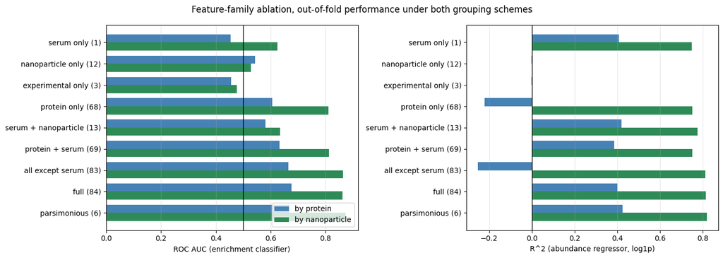

Nanoparticle features contribute little alone and matter through interactions. On their own they are worthless under nanoparticle-grouped CV (R2 0.000, AUC 0.529), which is expected: every nanoparticle feature is constant within a particle, so holding one out leaves them nothing to vary over. Added on top of everything else they are worth +0.047 R2 and +0.041 AUC, the largest marginal contribution of any family except protein.

The partition also explains Major 2. Exactly 69 of the 84 features are constant within every protein. The 15 that vary are the 12 nanoparticle features and the 3 experimental ones. Almost all of the information is carried on the protein axis, which is why holding out a nanoparticle costs so much less than holding out a protein.

Serum abundance behaves in the opposite way. Alone it already reaches R2 0.747, yet dropping it from the full set costs essentially nothing (-0.002 R2) because the 68 protein features carry the same information. Serum abundance is sufficient but not necessary, nanoparticle features are necessary but not sufficient, and the full model beats serum alone by 0.067 R2 (0.747 to 0.813).

```
wrote 2 tables to data
```

## Major 7. Evidence for dropping PEI

> *Figures 2 and 7 appear to show correlations between feature-importance values rather than correlations between the actual experimental features. These results do not directly show physical or biological relationships. The authors should clarify this point and provide stronger evidence before removing features such as PEI.*

Two independent lines of evidence follow:

1. Measured relationship between the two variables
2. Paired performance comparison of every model variant

### Evidence 1. The two variables are not merely correlated, they are redundant by construction

`ligand_pei` is a binary coating indicator and `zeta_potential` is continuous, evaluated at the 18 nanoparticle conditions.

```
Spearman(zeta_potential, ligand_pei) = 0.8212  (p = 0.00e+00)

Zeta potential by PEI coating, across the 18 NP conditions:
            count  min  max       mean
ligand_pei
0              12  -63   -3 -30.333333
1               6   12   39  26.666667

Separation: every PEI particle has zeta >= +12 mV, every non-PEI particle zeta <= -3 mV.
Any threshold in (-3, +12) mV recovers `ligand_pei` exactly: AUC(zeta -> PEI) = 1.000.
```

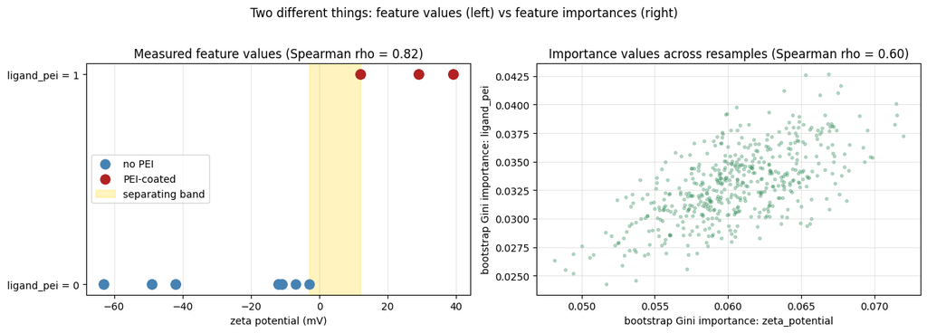

The two variables are not merely correlated, they are interchangeable. Every PEI-coated particle has a positive zeta potential (+12 to +39 mV) and every uncoated particle a negative one (-63 to -3 mV), so a single threshold anywhere in the gap reproduces `ligand_pei` exactly (AUC 1.000).

### Evidence 2. Paired performance comparison

Four variants of the parsimonious set, scored out-of-fold under both grouping schemes from Major 2, compared **fold by fold** against the full 7-feature set so the difference carries an interval rather than being a single-point comparison.

If `zeta_potential` and `ligand_pei` are redundant, dropping either alone should cost nothing while dropping both should hurt.

```
      by protein | PARSI_7 (both)             auc=0.6767
```

```
      by protein | PARSI_6 (drop ligand_pei)  auc=0.6691
```

```
      by protein | drop zeta_potential        auc=0.6567
```

```
      by protein | drop both                  auc=0.6346
```

```
 by nanoparticle | PARSI_7 (both)             auc=0.8733
```

```
 by nanoparticle | PARSI_6 (drop ligand_pei)  auc=0.8699
```

```
 by nanoparticle | drop zeta_potential        auc=0.8706
```

```
 by nanoparticle | drop both                  auc=0.8099
```

|  | scheme | variant | k | roc_auc | d_auc | d_auc_ci | d_auc_p | r2 | d_r2 | d_r2_ci | d_r2_p |
| --- | --- | --- | --- | --- | --- | --- | --- | --- | --- | --- | --- |
| 0 | by protein | PARSI_7 (both) | 7 | 0.6767 | 0.0000 | [+0.0000, +0.0000] | 1.0000 | 0.3159 | 0.0000 | [+0.0000, +0.0000] | 1.0000 |
| 1 | by protein | PARSI_6 (drop ligand_pei) | 6 | 0.6691 | -0.0076 | [-0.0220, +0.0067] | 0.4316 | 0.3137 | -0.0021 | [-0.0113, +0.0070] | 0.3750 |
| 2 | by protein | drop zeta_potential | 6 | 0.6567 | -0.0200 | [-0.0362, -0.0038] | 0.0371 | 0.3125 | -0.0033 | [-0.0248, +0.0181] | 0.6250 |
| 3 | by protein | drop both | 5 | 0.6346 | -0.0421 | [-0.0528, -0.0315] | 0.0020 | 0.3204 | 0.0045 | [-0.0302, +0.0393] | 0.8457 |
| 4 | by nanoparticle | PARSI_7 (both) | 7 | 0.8733 | 0.0000 | [+0.0000, +0.0000] | 1.0000 | 0.8121 | 0.0000 | [+0.0000, +0.0000] | 1.0000 |
| 5 | by nanoparticle | PARSI_6 (drop ligand_pei) | 6 | 0.8699 | -0.0033 | [-0.0103, +0.0036] | 0.2061 | 0.8120 | -0.0001 | [-0.0005, +0.0002] | 0.0674 |
| 6 | by nanoparticle | drop zeta_potential | 6 | 0.8706 | -0.0027 | [-0.0152, +0.0098] | 0.6377 | 0.7889 | -0.0232 | [-0.0520, +0.0056] | 0.0674 |
| 7 | by nanoparticle | drop both | 5 | 0.8099 | -0.0634 | [-0.1014, -0.0254] | 0.0068 | 0.7315 | -0.0806 | [-0.1255, -0.0357] | 0.0029 |

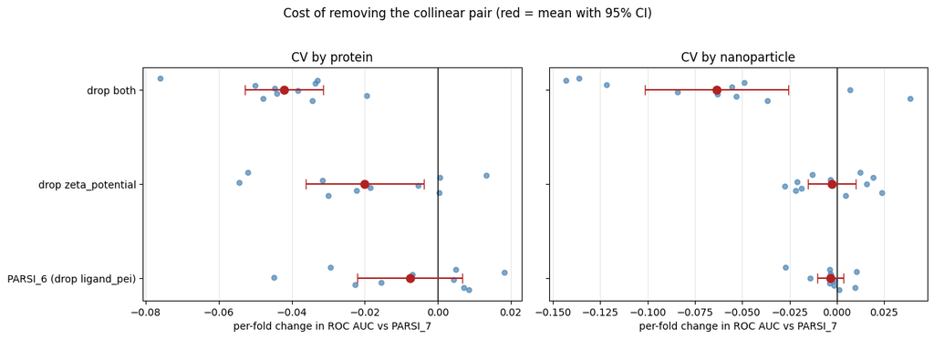

Dropping one of the pair is free, dropping both is not. Removing `ligand_pei` costs -0.003 AUC nanoparticle-grouped (p = 0.21) and -0.008 protein-grouped (p = 0.43), no detectable cost either way. Removing both costs -0.063 (p = 0.007) and -0.042 (p = 0.002).

It also settles which of the two to keep. Dropping `zeta_potential` instead costs -0.020 AUC protein-grouped (p = 0.037), so the continuous variable carries information the binary indicator does not.

```
wrote 2 tables to data
```

## Major 8. Predictive performance in full

> *The manuscript focuses on feature importance, but the predictive performance of the models is not presented in enough detail. The authors should report cross-validated regression metrics and classification metrics, including AUROC, precision-recall performance, calibration, and confidence intervals. Simple baseline models should also be included.*

Everything below is out-of-fold. Each model is evaluated under **both** grouping schemes from Major 2.

Metrics are computed the way `unified.ipynb` computes them: pool every held-out prediction, then score once. Confidence intervals are 95 % percentile intervals from 1000 bootstrap resamples of the unit the scheme blocked on - proteins when proteins were held out, nanoparticle materials when nanoparticles were - so the interval belongs to the same estimator as the point estimate.

Baselines included: majority class and stratified guessing for the classifier, the training mean for the regressor, penalised and unpenalised linear models for both, and the single-feature serum-abundance model from Major 5.

### Classification: metrics, baselines and confidence intervals

```
      by protein | RF, full 84                          auc=0.6769
```

```
      by protein | RF, parsimonious 6                   auc=0.6683
```

```
      by protein | RF, serum only                       auc=0.4543
```

```
      by protein | Logistic regression, full 84         auc=0.5665
```

```
      by protein | Logistic regression, parsimonious 6  auc=0.5556
```

```
      by protein | Baseline: majority class             auc=0.5000
```

```
      by protein | Baseline: stratified                 auc=0.4804
```

```
 by nanoparticle | RF, full 84                          auc=0.8615
```

```
 by nanoparticle | RF, parsimonious 6                   auc=0.8743
```

```
 by nanoparticle | RF, serum only                       auc=0.6241
```

```
 by nanoparticle | Logistic regression, full 84         auc=0.6295
```

```
 by nanoparticle | Logistic regression, parsimonious 6  auc=0.5721
```

```
 by nanoparticle | Baseline: majority class             auc=0.5000
```

```
 by nanoparticle | Baseline: stratified                 auc=0.4972
```

```
Class prevalence (enriched) = 0.391
```

|  | scheme | model | k | roc_auc | avg_precision | balanced_accuracy | f1 | brier |
| --- | --- | --- | --- | --- | --- | --- | --- | --- |
| 0 | by protein | RF, full 84 | 84 | 0.677 [0.643, 0.709] | 0.577 [0.521, 0.637] | 0.588 [0.564, 0.614] | 0.389 [0.331, 0.447] | 0.216 [0.208, 0.224] |
| 1 | by protein | RF, parsimonious 6 | 6 | 0.668 [0.634, 0.698] | 0.588 [0.533, 0.643] | 0.612 [0.583, 0.640] | 0.474 [0.419, 0.525] | 0.217 [0.207, 0.228] |
| 2 | by protein | RF, serum only | 1 | 0.454 [0.416, 0.497] | 0.382 [0.344, 0.436] | 0.524 [0.501, 0.550] | 0.229 [0.169, 0.295] | 0.272 [0.254, 0.291] |
| 3 | by protein | Logistic regression, full 84 | 84 | 0.566 [0.534, 0.600] | 0.438 [0.394, 0.488] | 0.542 [0.517, 0.567] | 0.378 [0.332, 0.425] | 0.249 [0.239, 0.261] |
| 4 | by protein | Logistic regression, parsimonious 6 | 6 | 0.556 [0.518, 0.592] | 0.423 [0.382, 0.477] | 0.498 [0.479, 0.517] | 0.149 [0.099, 0.203] | 0.239 [0.232, 0.247] |
| 5 | by protein | Baseline: majority class | 6 | 0.500 [0.500, 0.500] | 0.391 [0.363, 0.423] | 0.500 [0.500, 0.500] | 0.000 [0.000, 0.000] | 0.391 [0.363, 0.423] |
| 6 | by protein | Baseline: stratified | 6 | 0.480 [0.469, 0.492] | 0.382 [0.353, 0.415] | 0.480 [0.469, 0.492] | 0.375 [0.354, 0.397] | 0.498 [0.485, 0.512] |
| 7 | by nanoparticle | RF, full 84 | 84 | 0.862 [0.825, 0.892] | 0.809 [0.734, 0.862] | 0.775 [0.745, 0.798] | 0.721 [0.671, 0.755] | 0.145 [0.132, 0.161] |
| 8 | by nanoparticle | RF, parsimonious 6 | 6 | 0.874 [0.830, 0.911] | 0.815 [0.722, 0.883] | 0.797 [0.763, 0.821] | 0.751 [0.698, 0.784] | 0.137 [0.120, 0.158] |
| 9 | by nanoparticle | RF, serum only | 1 | 0.624 [0.595, 0.652] | 0.589 [0.524, 0.628] | 0.622 [0.606, 0.634] | 0.423 [0.396, 0.443] | 0.202 [0.196, 0.208] |
| 10 | by nanoparticle | Logistic regression, full 84 | 84 | 0.630 [0.586, 0.667] | 0.523 [0.451, 0.576] | 0.596 [0.556, 0.625] | 0.460 [0.346, 0.536] | 0.229 [0.220, 0.239] |
| 11 | by nanoparticle | Logistic regression, parsimonious 6 | 6 | 0.572 [0.529, 0.614] | 0.450 [0.392, 0.494] | 0.512 [0.503, 0.520] | 0.143 [0.107, 0.187] | 0.236 [0.227, 0.242] |
| 12 | by nanoparticle | Baseline: majority class | 6 | 0.500 [0.500, 0.500] | 0.391 [0.352, 0.418] | 0.500 [0.500, 0.500] | 0.000 [0.000, 0.000] | 0.391 [0.352, 0.418] |
| 13 | by nanoparticle | Baseline: stratified | 6 | 0.497 [0.489, 0.506] | 0.390 [0.351, 0.419] | 0.497 [0.489, 0.506] | 0.396 [0.373, 0.414] | 0.483 [0.475, 0.490] |

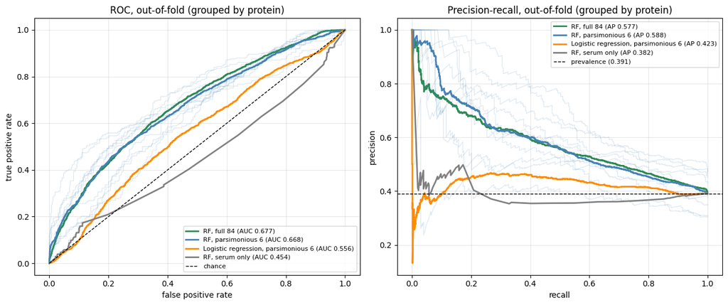

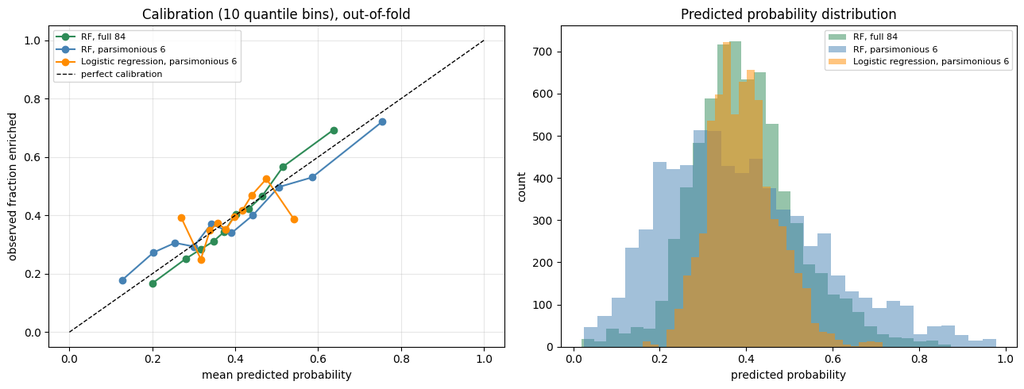

| model | brier | log_loss | mean_predicted | observed_rate | max_abs_gap |
| --- | --- | --- | --- | --- | --- |
| RF, full 84 | 0.2159 | 0.6202 | 0.3969 | 0.391 | 0.0561 |
| RF, parsimonious 6 | 0.2171 | 0.6247 | 0.3905 | 0.391 | 0.0701 |
| Logistic regression, parsimonious 6 | 0.2388 | 0.6709 | 0.3932 | 0.391 | 0.1560 |

Protein-grouped, the parsimonious forest reaches AUC 0.668 [0.634, 0.698] and average precision 0.588 [0.533, 0.643] against a prevalence floor of 0.391, above every baseline (majority class 0.500, logistic regression 0.556) and far below the 0.874 the nanoparticle-grouped scheme reports for the same model.

**Calibration**: mean predicted probability 0.390 against an observed rate of 0.391, with a maximum bin deviation of 0.070 versus 0.156 for logistic regression, so the predicted probabilities can be read as probabilities.

Serum abundance alone is *below* chance protein-grouped, AUC 0.454 [0.416, 0.497], and the interval excludes 0.5. That is the expected direction rather than an anomaly: the label is (corona / serum > 1), so a high serum value makes the ratio harder to clear.

### Regression: metrics, confidence intervals, and random forest vs linear regression

The comparison the response document asks for. `Ridge` and `LinearRegression` are fitted on standardised features. The nanoparticle core and ligand indicators are collinear by construction, so the unpenalised fit is rank-deficient and solved by least squares.

```
      by protein | RF, full 84                          r2=0.4009
```

```
      by protein | RF, parsimonious 6                   r2=0.4241
```

```
      by protein | RF, serum only                       r2=0.4059
```

```
      by protein | Linear regression, full 84           r2=0.4054
```

```
      by protein | Linear regression, parsimonious 6    r2=0.4260
```

```
      by protein | Ridge, full 84                       r2=0.4095
```

```
      by protein | Baseline: training mean              r2=-0.0029
```

```
 by nanoparticle | RF, full 84                          r2=0.8132
```

```
 by nanoparticle | RF, parsimonious 6                   r2=0.8186
```

```
 by nanoparticle | RF, serum only                       r2=0.7467
```

```
 by nanoparticle | Linear regression, full 84           r2=0.5023
```

```
 by nanoparticle | Linear regression, parsimonious 6    r2=0.4467
```

```
 by nanoparticle | Ridge, full 84                       r2=0.5019
```

```
 by nanoparticle | Baseline: training mean              r2=-0.0002
```

|  | scheme | model | k | r2 | mae | rmse | spearman_raw |
| --- | --- | --- | --- | --- | --- | --- | --- |
| 0 | by protein | RF, full 84 | 84 | 0.401 [0.196, 0.508] | 0.093 [0.073, 0.114] | 0.265 [0.206, 0.323] | 0.502 [0.432, 0.568] |
| 1 | by protein | RF, parsimonious 6 | 6 | 0.424 [0.209, 0.565] | 0.092 [0.072, 0.113] | 0.260 [0.209, 0.312] | 0.485 [0.416, 0.548] |
| 2 | by protein | RF, serum only | 1 | 0.406 [0.066, 0.619] | 0.094 [0.074, 0.116] | 0.264 [0.219, 0.306] | 0.212 [0.109, 0.306] |
| 3 | by protein | Linear regression, full 84 | 84 | 0.405 [0.194, 0.499] | 0.146 [0.128, 0.167] | 0.264 [0.216, 0.320] | 0.451 [0.375, 0.524] |
| 4 | by protein | Linear regression, parsimonious 6 | 6 | 0.426 [0.267, 0.507] | 0.111 [0.091, 0.134] | 0.260 [0.202, 0.329] | 0.389 [0.302, 0.471] |
| 5 | by protein | Ridge, full 84 | 84 | 0.409 [0.198, 0.503] | 0.145 [0.127, 0.166] | 0.263 [0.216, 0.320] | 0.454 [0.381, 0.527] |
| 6 | by protein | Baseline: training mean | 6 | -0.003 [-0.015, -0.002] | 0.151 [0.127, 0.180] | 0.343 [0.250, 0.446] | -0.045 [-0.129, 0.037] |
| 7 | by nanoparticle | RF, full 84 | 84 | 0.813 [0.754, 0.867] | 0.047 [0.040, 0.053] | 0.148 [0.124, 0.171] | 0.729 [0.686, 0.766] |
| 8 | by nanoparticle | RF, parsimonious 6 | 6 | 0.819 [0.751, 0.876] | 0.046 [0.040, 0.054] | 0.146 [0.120, 0.172] | 0.739 [0.683, 0.783] |
| 9 | by nanoparticle | RF, serum only | 1 | 0.747 [0.684, 0.802] | 0.059 [0.053, 0.065] | 0.172 [0.151, 0.193] | 0.396 [0.358, 0.439] |
| 10 | by nanoparticle | Linear regression, full 84 | 84 | 0.502 [0.453, 0.535] | 0.129 [0.125, 0.134] | 0.242 [0.232, 0.254] | 0.456 [0.432, 0.471] |
| 11 | by nanoparticle | Linear regression, parsimonious 6 | 6 | 0.447 [0.401, 0.477] | 0.110 [0.106, 0.114] | 0.255 [0.247, 0.265] | 0.384 [0.358, 0.405] |
| 12 | by nanoparticle | Ridge, full 84 | 84 | 0.502 [0.453, 0.534] | 0.129 [0.125, 0.134] | 0.242 [0.233, 0.254] | 0.458 [0.435, 0.472] |
| 13 | by nanoparticle | Baseline: training mean | 6 | -0.000 [-0.001, -0.000] | 0.151 [0.147, 0.154] | 0.343 [0.338, 0.347] | -0.080 [-0.132, -0.030] |

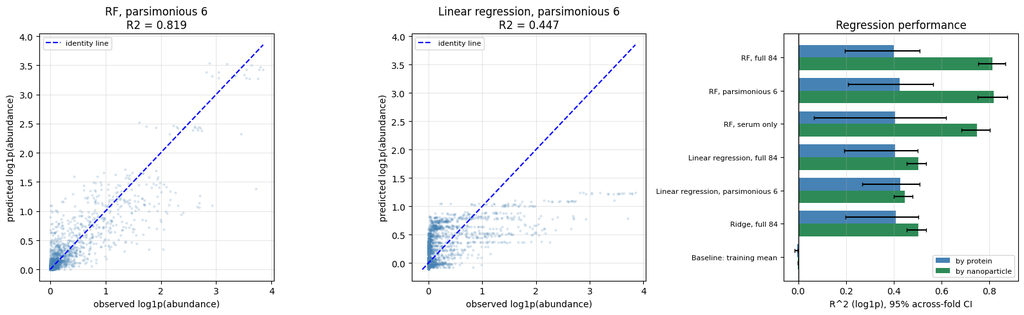

With nanoparticles held out, the gain over a linear model is non-linearity rather than regularisation. The parsimonious forest reaches R2 0.819 [0.751, 0.876] against 0.447 for linear regression on the same six features and 0.502 for both ridge and unpenalised least squares on all 84. Ridge and OLS agree to three decimals, so the penalty is doing nothing and the whole difference is the functional form.

With proteins held out, that gain disappears. The forest (0.424 [0.209, 0.565]), linear regression (0.426 [0.267, 0.507]), ridge (0.409) and a forest given serum abundance *alone* (0.406 [0.066, 0.619]) are indistinguishable. Predicting abundance for an unseen protein is essentially predicting its serum abundance, and no model here does better than that. This is the same structural fact as Major 2 and Major 5 seen from a third angle - the regression generalises across nanoparticles, not across proteins.

```
wrote 5 tables to data
```

## Major 9. Number of clusters, cluster stability, and labelling

> *The authors selected three K-means clusters without clearly explaining why three was chosen. The labels "always" and "never" are also too strong because the average probabilities are not 1.0 or 0. The authors should justify the number of clusters, evaluate cluster stability, and use less absolute labels.*

```
response matrices: detection (376, 6), enrichment (376, 6)
```

### Choosing *k*: elbow and silhouette

Inertia plus mean silhouette width, which unlike inertia has an interior optimum and so can actually select a *k*.

| target k | inertia detection | inertia enrichment | silhouette detection | silhouette enrichment |
| --- | --- | --- | --- | --- |
| 2 | 85.1257 | 84.3411 | 0.5816 | 0.5367 |
| 3 | 57.1860 | 60.4305 | 0.4953 | 0.4475 |
| 4 | 37.6014 | 38.2349 | 0.4942 | 0.4776 |
| 5 | 30.9721 | 31.3509 | 0.4938 | 0.4159 |
| 6 | 24.8793 | 26.2862 | 0.4754 | 0.4242 |
| 7 | 21.1286 | 23.3063 | 0.4383 | 0.3696 |
| 8 | 18.7858 | 21.1252 | 0.4201 | 0.3666 |
| 9 | 16.7760 | 19.3266 | 0.4042 | 0.3423 |
| 10 | 15.3667 | 17.3894 | 0.3862 | 0.3488 |

Inertia falls smoothly with no elbow (85, 57, 38, 31 for detection), and the silhouette maximum is at k = 2 for both targets (0.582 and 0.537, against 0.495 and 0.448 at k = 3). For enrichment even k = 4 scores higher than k = 3.

### Stability: does the same partition reappear under resampling?

For each *k*, refit K-means on 100 random 80 % subsamples of the proteins and compare each result with the reference partition restricted to the same proteins (adjusted Rand index). A partition that only exists in one particular sample of proteins will score poorly here. Per-cluster Jaccard similarity is also reported for *k* = 3, which shows whether *all three* clusters are stable or only some of them.

```
done: detection
```

```
done: enrichment
```

| target k | ari_mean detection | ari_mean enrichment | ari_sd detection | ari_sd enrichment |
| --- | --- | --- | --- | --- |
| 2 | 0.9801 | 0.9973 | 0.0336 | 0.0113 |
| 3 | 0.9712 | 0.7329 | 0.0379 | 0.2752 |
| 4 | 0.9605 | 0.9593 | 0.0238 | 0.0332 |
| 5 | 0.8098 | 0.9625 | 0.1325 | 0.0416 |
| 6 | 0.8875 | 0.9526 | 0.0680 | 0.0376 |
| 7 | 0.9355 | 0.8686 | 0.0676 | 0.1014 |
| 8 | 0.8710 | 0.8029 | 0.0945 | 0.0987 |
| 9 | 0.8708 | 0.7775 | 0.0752 | 0.0904 |
| 10 | 0.8435 | 0.7566 | 0.0560 | 0.1030 |

|  | target | cluster | n | mean_prob | zeta_sensitivity | jaccard |
| --- | --- | --- | --- | --- | --- | --- |
| 0 | detection | 0 | 198 | 0.211 | 0.322 | 0.992 |
| 1 | detection | 1 | 80 | 0.537 | 0.467 | 0.946 |
| 2 | detection | 2 | 98 | 0.917 | 0.101 | 0.968 |
| 3 | enrichment | 0 | 218 | 0.194 | 0.292 | 0.837 |
| 4 | enrichment | 1 | 73 | 0.468 | 0.490 | 0.644 |
| 5 | enrichment | 2 | 85 | 0.807 | 0.251 | 0.833 |

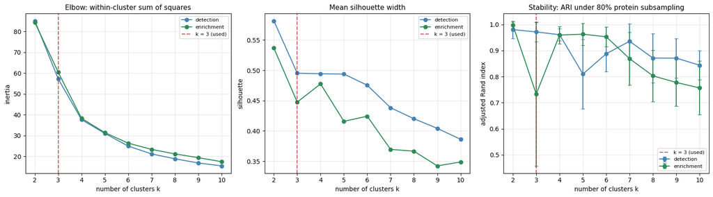

The detection clustering at k = 3 is solid: ARI 0.971 +/- 0.038 under 80 % protein subsampling, with every cluster above 0.94 Jaccard.

The enrichment clustering at k = 3 is the least stable choice anywhere in the range tested (ARI 0.733 +/- 0.275, against 0.997 at k = 2 and 0.959 at k = 4). The weak cluster is the *intermediate* one, Jaccard 0.644, so roughly a third of its membership changes from one resample to the next. The low and high clusters hold at 0.837 and 0.833. That is at least coherent with what the group is: proteins that sit firmly in neither mode.

```
wrote 3 tables to data
```